# Day 2 lectures and exercises

## Read in the Titanic mortality data set

The following is for my own benefit. You do not need to run this.

```r
rm(list=ls())
```

You should find the data file on mortality among passengers of the Titanic at

–> http://www.statsci.org/data/general/titanic.txt

A brief description of this file is available at

–> http://www.statsci.org/data/general/titanic.html

You need to read in the file using the read.table function.

```r
# ti <- read.table(file="http://www.statsci.org/data/general/titanic.txt")
```

There is an issue on the 38th line of the file. You need to download the file and fix it and then read it locally.

```r
# ti <- read.table(file="day2_titanic_v02.txt")
```

Oops! There is one more problem, fix this, save under a different name and then read it in.

```r
ti <- read.table(file="day2_titanic_v03.txt")
head(ti)
```

```
##                                              V1     V2   V3     V4
## 1                                          Name PClass  Age    Sex
## 2                  Allen, Miss Elisabeth Walton    1st   29 female
## 3                   Allison, Miss Helen Loraine    1st    2 female
## 4           Allison, Mr Hudson Joshua Creighton    1st   30   male
## 5 Allison, Mrs Hudson JC (Bessie Waldo Daniels)    1st   25 female
## 6                 Allison, Master Hudson Trevor    1st 0.92   male
##         V5
## 1 Survived
## 2        1
## 3        0
## 4        0
## 5        0
## 6        1
```

```r
tail(ti)
```

```
##                          V1  V2   V3     V4 V5
## 1309    Zabour, Miss Tamini 3rd <NA> female  0
## 1310     Zakarian, Mr Artun 3rd   27   male  0
## 1311 Zakarian, Mr Maprieder 3rd   26   male  0
## 1312       Zenni, Mr Philip 3rd   22   male  0
## 1313       Lievens, Mr Rene 3rd   24   male  0
## 1314         Zimmerman, Leo 3rd   29   male  0
```

Darn it all, we almost have it. But the variable names are listed as the first row of the data set. Take a look at the help file for the read.table function to see how to fix this.

```r
ti <- read.table(file="day2_titanic_v03.txt",header=TRUE)
head(ti)
```

```
##                                            Name PClass   Age    Sex
## 1                  Allen, Miss Elisabeth Walton    1st 29.00 female
## 2                   Allison, Miss Helen Loraine    1st  2.00 female
## 3           Allison, Mr Hudson Joshua Creighton    1st 30.00   male
## 4 Allison, Mrs Hudson JC (Bessie Waldo Daniels)    1st 25.00 female
## 5                 Allison, Master Hudson Trevor    1st  0.92   male
## 6                            Anderson, Mr Harry    1st 47.00   male
##   Survived
## 1        1
## 2        0
## 3        0
## 4        0
## 5        1
## 6        1
```

```r
tail(ti)
```

```
##                        Name PClass Age    Sex Survived
## 1308    Zabour, Miss Tamini    3rd  NA female        0
## 1309     Zakarian, Mr Artun    3rd  27   male        0
## 1310 Zakarian, Mr Maprieder    3rd  26   male        0
## 1311       Zenni, Mr Philip    3rd  22   male        0
## 1312       Lievens, Mr Rene    3rd  24   male        0
## 1313         Zimmerman, Leo    3rd  29   male        0
```

Notice that Miss Tamini Zabour has an “NA” for age. We’ll take a careful look at this later.

## On your own

Who is the oldest passenger on the Titanic. Did he/she survive?

## Categorical versus continuous variables

A categorical variable is defined (loosely) as a variable that has a small number of possible values. Each value is usually associated with a particular category or label. In contrast, a continuous variable is defined as a variable that has a large number of possible values, potentially any value in a particular interval.

Yesterday, almost all of the variables that you used were continuous. Today, almost all of the variables that you will use will be categorical.

The distinction between continuous and categorical variables is important in deciding what types of descriptive and inferential statistics you should use. But, there is often gray and fuzzy line between categorical and continuous variables. Don’t worry too much about this today. If you’re not sure whether a variable is categorical or continuous, try some simple descriptive statistics and graphs appropriate for categorical data and then try some simple descriptive statistics and graphs for continuous data. You will usually figure out quickly whehther treating your variable as categorical or continuous makes the most sense.

There are other types of variables also, such as count variables, that have their own special features.

## Frequency counts

For categorical variables, you should first get frequency counts.

```r
table(ti$PClass)
```

```
##
## 1st 2nd 3rd
## 322 280 711
```

Unlike most other statistical packages, R tends to have a minimalist approach to statistics. So the table function produces only counts. If you want percentages in addition to counts, there are several approaches.

The prop.table function takes a frequency table and converts it to a proportion.

```r
tb <- table(ti$PClass)
prop.table(tb)
```

```
##
##       1st       2nd       3rd
## 0.2452399 0.2132521 0.5415080
```

Multiply by 100 and round to get percentages.

```r
pct <- round(100*prop.table(tb))
pct
```

```
##
## 1st 2nd 3rd
##  25  21  54
```

You can get even fancier. The paste function concatenates several string variables and if something is not a string, R will convert it to a string before concatenating.

```r
pct.sign <- "%"
paste(pct,pct.sign,sep="")
```

```
## [1] "25%" "21%" "54%"
```

Somehow, the names of the passenger class got lost. So let’s add them back in.

```r
paste(names(pct),pct,pct.sign,sep="")
```

```
## [1] "1st25%" "2nd21%" "3rd54%"
```

You can add spacing and a bit of punctuation to make the output look more readable.

```r
colon <- ": "
paste(names(tb),colon,pct,pct.sign,sep="")
```

```
## [1] "1st: 25%" "2nd: 21%" "3rd: 54%"
```

Finally, you can combine the counts and the total with the percents to make things look really nice.

```r
n  <- sum(tb)
slash <- "/"
comma <- ", "
paste(names(tb),colon,tb,slash,n,comma,pct,pct.sign,sep="")
```

```
## [1] "1st: 322/1313, 25%" "2nd: 280/1313, 21%" "3rd: 711/1313, 54%"
```

This shows how I like to program in R. First, get something simple. Then slowly add layers to it until you get a nice polished product.

In contrast, most other statistical packages try to produce polished results right from the start. This has some advantages, but the approach used by R, where many of the functions do something simple and basic, allows you to polish the results the way you want them.

# Tables that include counts of missing values.

The default option in the table function is to not list missing values. During the intitial data screening, you should always look for missing values. This is done with the useNA argument.

```r
table(ti$PClass,useNA="always")
```

```
##
##  1st  2nd  3rd <NA>
##  322  280  711    0
```

You can add a total count to the frequency table with the addmargins function.

```r
addmargins(table(ti$PClass,useNA="always"))
```

```
##
##  1st  2nd  3rd <NA>  Sum
##  322  280  711    0 1313
```

## On your own

Run frequency counts for Sex and Survived. Be sure to look for missing values for these two variables.

## Use of the summary function

Last time, we learned about the summary function, which produced the minimum, maximum, quartiles, mean, and missing value counts. Summary will actually look at the argument being passed to it and try to produce different summary statistics based on what the argument looks like. This, in technical terms, is an object-oriented feature of the R programming language (the use of classes and methods, to be more specificd).

If the argument sent to summary is a character vector rather than a numeric vector, it will use frequency counts. So notice the difference between

```r
summary(ti$PClass)
```

```
## 1st 2nd 3rd
## 322 280 711
```

and

```r
summary(ti$Age)
```

```
##    Min. 1st Qu.  Median    Mean 3rd Qu.    Max.    NA's
##    0.17   21.00   28.00   30.40   39.00   71.00     557
```

Sometimes this is very nice but sometimes it is not so nice.

```r
summary(ti$Sex)
```

```
## female   male
##    462    851
```

```r
summary(ti$Survived)
```

```
##    Min. 1st Qu.  Median    Mean 3rd Qu.    Max.
##  0.0000  0.0000  0.0000  0.3427  1.0000  1.0000
```

## Factors

When you have a categorical variable that uses number codes, you need to either handle this as a special case, or you need to create a factor variable.

```r
ti$surv.factor <- factor(ti$Survived,levels=0:1,labels=c("No","Yes"))
summary(ti$surv.factor)
```

```
##  No Yes
## 863 450
```

The factor function is similar to the variable label in SPSS and the format statement in SAS. It assigns category names (No and Yes) to numeric codes (0 and 1). It also has other features that are helpful in linear and logistic regression models, such as the ability to specify contrasts.

## Bar plots

I’m not a big fan of bar plots, but they sometimes have their uses. You can get a barplot for the frequency count

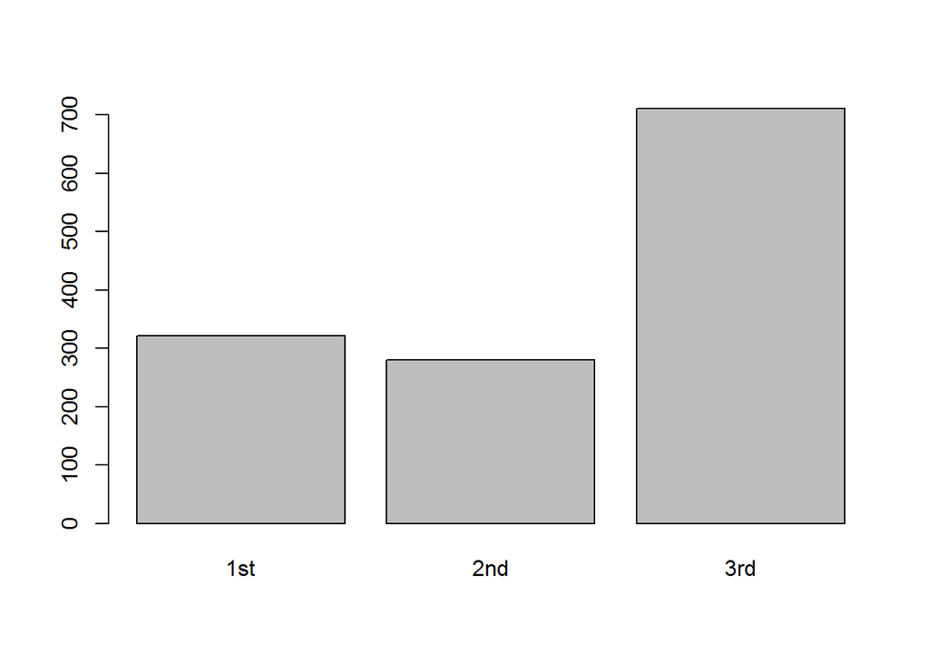

```r
barplot(table(ti$PClass))
```

or for the percentage (note the use of the ylab argument here).

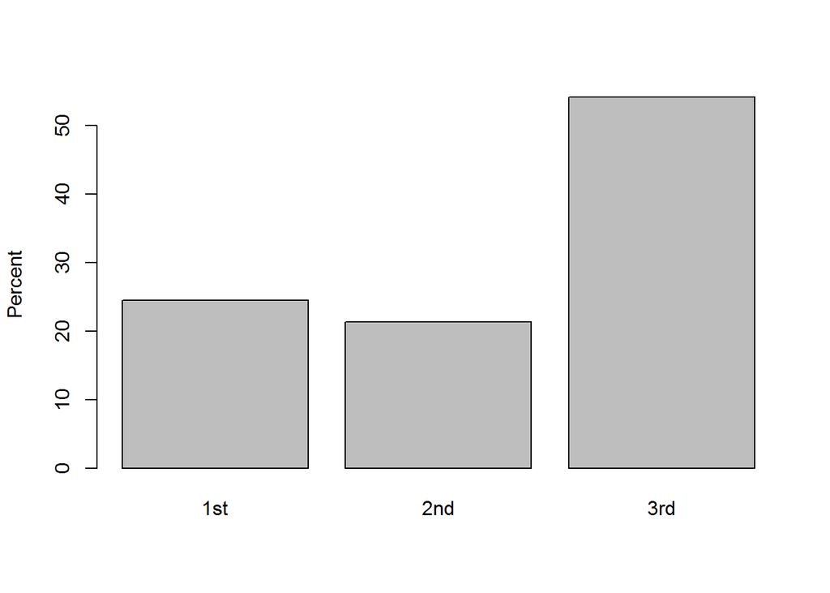

```r
barplot(100*prop.table(table(ti$PClass)),ylab="Percent")
```

You can make things even nicer by pasting a percent sign on the vertical axis tick marks.

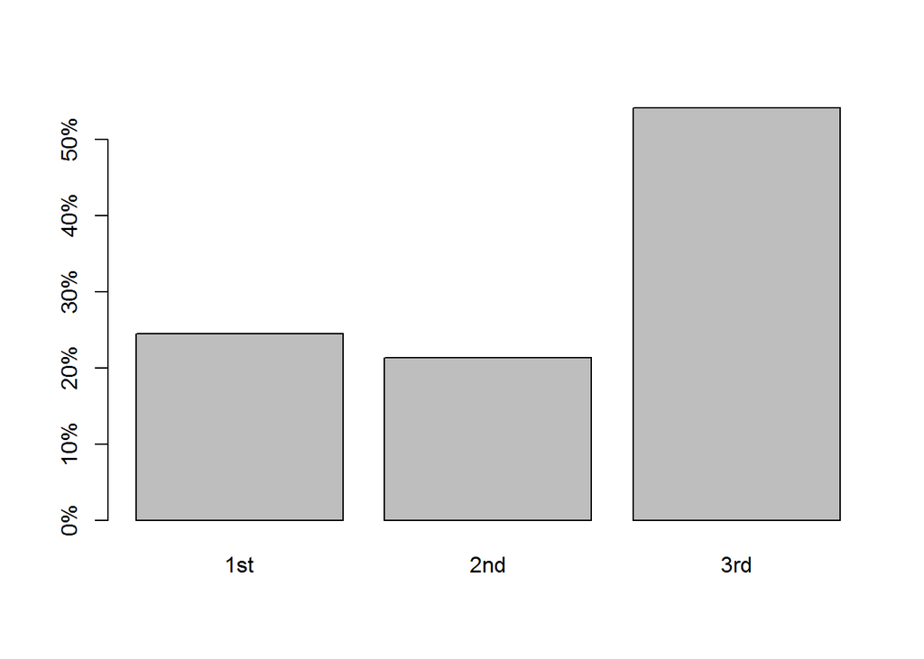

```r
barplot(100*prop.table(table(ti$PClass)),axes=FALSE)
axis(side=2,at=10*(0:5),labels=paste(10*(0:5),"%",sep=""))
```

## On your own

Add label “Passenger class” to the x-axis of this bar plot.

## Crosstabulations

When you are looking at the relationship between two categorical variables, you need to start with a crosstabulation. You use the table function in R with two arguments to create a crosstabulation.

```r
table(ti$PClass,ti$surv.factor)
```

```
##
##        No Yes
##   1st 129 193
##   2nd 161 119
##   3rd 573 138
```

The first variable is the rows and the second variable is the columns.

As a general rule of thumb, if one variable tends to have a lot of categories, I tend to put that in the rows. This allows you to scan the many categories with an up/down scroll rather than a left/right scroll. There are other rules of thumb for which variable to choose for your rows and which to choose for your columns in a crosstabulation.

Again, notice that R is rather minimalist in its approach. You do not see any row or column totals. You can get these with the addmargins function.

```r
ct <- table(ti$PClass,ti$surv.factor)
addmargins(ct,1)
```

```
##
##        No Yes
##   1st 129 193
##   2nd 161 119
##   3rd 573 138
##   Sum 863 450
```

```r
addmargins(ct,2)
```

```
##
##        No Yes Sum
##   1st 129 193 322
##   2nd 161 119 280
##   3rd 573 138 711
```

```r
addmargins(ct)
```

```
##
##         No  Yes  Sum
##   1st  129  193  322
##   2nd  161  119  280
##   3rd  573  138  711
##   Sum  863  450 1313
```

## Table percentages.

Percentages in a crosstabulation are actually quite tricky. You can compute a percentage across the entire table (which would be called a cell percent in SPSS and SAS). It helps to round these results.

```r
prop.table(ct)
```

```
##
##               No        Yes
##   1st 0.09824829 0.14699162
##   2nd 0.12261995 0.09063214
##   3rd 0.43640518 0.10510282
```

```r
round(100*prop.table(ct))
```

```
##
##       No Yes
##   1st 10  15
##   2nd 12   9
##   3rd 44  11
```

These percentages add to 100% across all of the table. In contrast, row percentages add up to 100% within each row.

```r
round(100*prop.table(ct,margin=1))
```

```
##
##       No Yes
##   1st 40  60
##   2nd 57  42
##   3rd 81  19
```

This is a rather cryptic command and it shows one area for R where getting simple statistics is a lot harder than in SAS or SPSS.

Column percentages add up to 100% within each column.

```r
round(100*prop.table(ct,margin=2))
```

```
##
##       No Yes
##   1st 15  43
##   2nd 19  26
##   3rd 66  31
```

It is not always clear whether you should use row, column, or cell percents. You can find some general advice at –> http://www.pmean.com/02/percentage.html but to be honest, the best approach is to try several approaches and see what works best. I have found that I usually like row percentages in a crosstabulation with your outcome variables as the columns.

## On your own

Compute a table showing the relationship between sex and survival. The Titanic sunk during a time when people really did believe in the phrase “women and children first”. Find a table of percentages that shows the degree to which women were more likely to survive than men.

## Creating new categorical variables

There are several ways to create a new categorical variable in R, but the easiest way is through the use of logical comparisons.

Suppose you wanted to compute a categorical variable called “child” which is equal to 1 if a passenger is less than 18 years old and 0 if a passenger is 18 or older. Here’s one way to do it.

```r
ti$child <- as.numeric(ti$Age<18)
```

Anytime you create a new categorical variable, you should run a crosstabulation to check your results. Pay special attention to how missing values are handled. I’m only printing out the head and the tail to save space, but you should look at the entire table.

```r
chk <- table(ti$Age,ti$child,useNA="always")
head(chk)
```

```
##
##        0 1 <NA>
##   0.17 0 1    0
##   0.33 0 1    0
##   0.8  0 1    0
##   0.83 0 2    0
##   0.92 0 1    0
##   1    0 5    0
```

```r
tail(chk)
```

```
##
##        0 1 <NA>
##   65   2 0    0
##   67   1 0    0
##   69   1 0    0
##   70   1 0    0
##   71   3 0    0
##   <NA> 0 0  557
```

Note that since age has lots of values, we prefer to use that as the rows in the crosstabulation.

## On your own

Redfine a child as anyone under 21 years of age. Use the factor function to create labels of “adult” for 0 and “child” for 1. Are children more likely to survive than adults?

## More on recoding

Sometimes you want to combine two or more of hte categories together. Here is how you might create a new passenger class variable with values of 1 for second and third class and 0 for first class.

The vertical bar (|) is the R symobl for logical OR.

As before, it’s a good a idea to run a crosstabulation to verify that the new coding was done properly.

```r
ti$lower.class <- as.numeric(ti$PClass=="2nd" | ti$PClass=="3rd")
table(ti$PClass,ti$lower.class)
```

```
##
##         0   1
##   1st 322   0
##   2nd   0 280
##   3rd   0 711
```

## Creating multi-level categories

You can create multi-level categories using a complex logic system, but you can do it simpler and faster with the cut function.

```r
ti$age.groups <- cut(ti$Age,breaks=c(0,2,6,9,12,19,99))
table(ti$age.groups,useNA="always")
```

```
##
##   (0,2]   (2,6]   (6,9]  (9,12] (12,19] (19,99]    <NA>
##      20      21      12       7      89     607     557
```

The notation used by cut may be familiar to mathematicians who know the difference between open and closed sets, but you can choose different labels.

```r
lb <- c("Infant","Toddler","Child","Tween","Teenager","Adult")
ti$age.groups <- cut(ti$Age,breaks=c(0,2,6,9,12,19,99),labels=lb)
table(ti$age.groups,useNA="always")
```

```
##
##   Infant  Toddler    Child    Tween Teenager    Adult     <NA>
##       20       21       12        7       89      607      557
```

## Odds ratios and relative risks

The odds ratio and the relative risk are two measures that summarize the relationship between two categorical variables. They are most easily computed for binary variables, but there are extensions for variables with more than two categories.

The computation of odds ratios or relative risks and their associated confidence intervals requires the use of a special library. There are several that work well, but I am partial to “epitools”.

```r
# install.packages("epitools",repos="http://rweb.quant.ku.edu/cran/")
library("epitools")
```

The oddsratio function computes the odds ratio and its 95% confidence interval.

```r
oddsratio(ti$Sex,ti$Survived)
```

```
## $data
##          Outcome
## Predictor   0   1 Total
##    female 154 308   462
##    male   709 142   851
##    Total  863 450  1313
##
## $measure
##          odds ratio with 95% C.I.
## Predictor  estimate      lower     upper
##    female 1.0000000         NA        NA
##    male   0.1004472 0.07686819 0.1305053
##
## $p.value
##          two-sided
## Predictor midp.exact fisher.exact   chi.square
##    female         NA           NA           NA
##    male            0 4.826448e-74 3.425855e-74
##
## $correction
## [1] FALSE
##
## attr(,"method")
## [1] "median-unbiased estimate & mid-p exact CI"
```

Notice that this output is quite verbose. You can still choose to print only the parts that you want, though.

```r
oddsratio(ti$Sex,ti$Survived)$measure
```

```
##          odds ratio with 95% C.I.
## Predictor  estimate      lower     upper
##    female 1.0000000         NA        NA
##    male   0.1004472 0.07686819 0.1305053
```

```r
oddsratio(ti$Sex,ti$Survived)$measure[2,1]
```

```
## [1] 0.1004472
```

Note that the odds of dying are 2 to 1 against for women and 5 to 1 in favor for men. This corresponds to an odds ratio of 1/10 (if you put men in the denominator) or 10 (if you put women in the denominator).

The oddsratio function has a nice feature that allows you to reverse the order of the rows and columns, and thus control what goes in your denominator.

```r
oddsratio(ti$Sex,ti$Survived,rev="rows")
```

```
## $data
##          Outcome
## Predictor   0   1 Total
##    male   709 142   851
##    female 154 308   462
##    Total  863 450  1313
##
## $measure
##          odds ratio with 95% C.I.
## Predictor estimate    lower    upper
##    male   1.000000       NA       NA
##    female 9.956188 7.662525 13.00928
##
## $p.value
##          two-sided
## Predictor midp.exact fisher.exact   chi.square
##    male           NA           NA           NA
##    female          0 4.826448e-74 3.425855e-74
##
## $correction
## [1] FALSE
##
## attr(,"method")
## [1] "median-unbiased estimate & mid-p exact CI"
```

The relative risk and its associated confidence intervals are also available in the epitools library, though it uses a different term (risk ratio).

```r
riskratio(ti$Sex,ti$Survived)
```

```
## $data
##          Outcome
## Predictor   0   1 Total
##    female 154 308   462
##    male   709 142   851
##    Total  863 450  1313
##
## $measure
##          risk ratio with 95% C.I.
## Predictor  estimate     lower     upper
##    female 1.0000000        NA        NA
##    male   0.2502938 0.2125647 0.2947195
##
## $p.value
##          two-sided
## Predictor midp.exact fisher.exact   chi.square
##    female         NA           NA           NA
##    male            0 4.826448e-74 3.425855e-74
##
## $correction
## [1] FALSE
##
## attr(,"method")
## [1] "Unconditional MLE & normal approximation (Wald) CI"
```

This is actually the wrong risk ratio. The probability of dying is 83% (about 5/6) among the men and 33% (exactly 1/3) among the women. The ratio of these two probabilities is 2.5 (if you put women in the denominator) or 0.4 (if you put men in the denominator). What epitools gives you by default is the relative risk for the second column of your table. For ti$Survived, you are computing the relative risk of living. You can fix this two different ways.

```r
ti$died <- 1-ti$Survived
riskratio(ti$Sex,ti$died)
```

```
## $data
##          Outcome
## Predictor   0   1 Total
##    female 308 154   462
##    male   142 709   851
##    Total  450 863  1313
##
## $measure
##          risk ratio with 95% C.I.
## Predictor estimate    lower    upper
##    female 1.000000       NA       NA
##    male   2.499412 2.189428 2.853285
##
## $p.value
##          two-sided
## Predictor midp.exact fisher.exact   chi.square
##    female         NA           NA           NA
##    male            0 4.826448e-74 3.425855e-74
##
## $correction
## [1] FALSE
##
## attr(,"method")
## [1] "Unconditional MLE & normal approximation (Wald) CI"
```

```r
riskratio(ti$Sex,ti$Survived,rev="columns")
```

```
## $data
##          Outcome
## Predictor   1   0 Total
##    female 308 154   462
##    male   142 709   851
##    Total  450 863  1313
##
## $measure
##          risk ratio with 95% C.I.
## Predictor estimate    lower    upper
##    female 1.000000       NA       NA
##    male   2.499412 2.189428 2.853285
##
## $p.value
##          two-sided
## Predictor midp.exact fisher.exact   chi.square
##    female         NA           NA           NA
##    male            0 4.826448e-74 3.425855e-74
##
## $correction
## [1] FALSE
##
## attr(,"method")
## [1] "Unconditional MLE & normal approximation (Wald) CI"
```

## On your own

Examine the relationship between passenger class and survival using both odds ratios and relative risks. Try these functions both with and without the rev=“rows” argument.

## Left to do: analyze a second data set.

The Gardasil vaccine requires three shots in order to be effective. A study conducted at Johns Hopkins looked at how often patients failed to get all three shots. They wanted to see if insurance status, age, and other factors could predict who was at greatest risk for failing to get all three shots.

The data set is available as an Excel spreadsheet at –> http://www.amstat.org/publications/jse/v19n1/gardasil.xls

and a description of the file is available at –> http://www.amstat.org/publications/jse/v19n1/gardasil.txt

Note to myself. I have not run through the analysis of this data set, yet, but it should have many of the same features as the Titanic data set, as almost all of the variables are categorical.

```r
fn <- "day2_gardasil.csv"
ga <- read.csv(fn)
```

## On your own

1. Create factors for AgeGroup, Race, Completed, Location.
2. Report which variables have missing data and how many of these values are missing.
3. What proportion of patients completed all three shots?
4. Draw a bar chart showing the percentage of patients at each of the four locations.
5. Use a crosstabulation to compare Age to AgeGroup, and Location to LocationType. Are the recodings into AgeGroup and LocationType done properly?
6. Create a new variable that combines the race categories into white, and non-white. Calculate the proportion of white patients at each of the four locations.
7. Does the likelihood of completing all four shots vary by AgeGroup, Race, or Location? Calculate the appropriate percentages and relative risks.
8. Place all the key results into a Word document, add a bit of commentary, and turn it in.

## A third data set

If there is time, here is a third data set

diet <- read.table(“http://lib.stat.cmu.edu/DASL/Datafiles/Fiber.html”, skip=26,comment.char=“<”,header=TRUE)

## Save all my work

```r
save.image("day2.RData")
```